# Introduction to AGB

## A regression example

We consider the following datasets:

```r
library(tidyverse)
n <- 2000
d <- 10
X <- matrix(runif(n*d,-1,1),nrow=n) %>% data.frame()
Y <- X$X1*X$X2+X$X3^2-X$X4*X$X7+X$X8*X$X10-X$X6^2+rnorm(n,0,sqrt(0.5))
df <- X
df$Y <- Y
```

Most of the parameters of **agb** are similar to parameters in **gbm**:

- *formula*: description oh the model to be fit.
- *data*: a data frame which contains the train and validation dataset.
- *nesterov*: TRUE for the Nesterov accelerated gradient, FALSE for standard gradient boosting
- *train.fraction*: the first train.fraction * nrows(data) observations are used to fit the model. Other observations define the validation data set to select the number of iterations.
- *n.trees*: the total number on trees to fit.
- *shrinkage*: the shrinkage parameter of the algorithm.
- *new.data*: a test data set.
- *distribution*: a character string specifying the loss function. “Gaussian” for $L_2$-boosting, “adaboost” for the exponential loss and “bernoulli” for the logit-boost loss.
- *depth.tree*: depth of the tree (stumps by default).
- *n.minobsinnode*: minimum number of observations in the trees terminal nodes. Note that this is the actual number of observations not the total weight.

We obtain the accelerated gradient boosting with

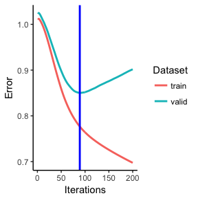

```r
source("agb_v1.R")
m1 <- agb(Y~.,data=df[1:1500,],distribution="gaussian",nesterov=TRUE,n.trees=200)
m1$graph
```

and the standard gradient boosting machine with

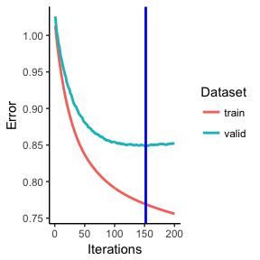

```r
m2 <- agb(Y~.,data=df[1:1500,],distribution="gaussian",nesterov=FALSE,shrinkage=0.1,n.trees=200)
m2$graph
```

## A binary classification example

We consider the spam dataset:

```r
library(kernlab)
data(spam)
```

For classification problem, **agb** requires 0/1 output

```r
spam1 <- spam
spam1$type <- as.numeric(spam1$type)-1
```

We can run the **adaboost** and **logitboost** accelerated boosting with

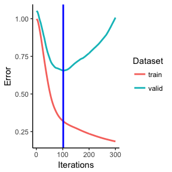

```r
m3 <- agb(type~.,data=spam1,distribution="adaboost",n.trees=300)
m4 <- agb(type~.,data=spam1,distribution="bernoulli",n.trees=300)
m3$graph
```

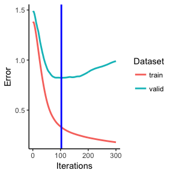

```r
m4$graph
```